# Project 2: King County Housing Data

Dr. Lasanthi Watagoda

4/24/2018

Variable descriptions were obtained from King County, Department of Assessments. All feature engineering should be done in the first code chunks of your document.

- id - Unique ID for each home sold
- date - Date of the home sale
- price - Price of each home sold
- bedrooms - Number of bedrooms
- bathrooms - Number of bathrooms, where .5 accounts for a room with a toilet but no shower
- sqft_living - Square footage of the apartments interior living space
- sqft_lot - Square footage of the land space
- floors - Number of floors
- waterfront - A dummy variable for whether the apartment was overlooking the waterfront or not * 1’s represent a waterfront property, 0’s represent a non-waterfront property
- view - An index from 0 to 4 of how good the view of the property was, 0 - lowest, 4 - highest
- condition - An index from 1 to 5 on the condition of the apartment, 1 - lowest, 4 - highest
- grade - An index from 1 to 13, where 1-3 falls short of building construction and design, 7 has an average level of construction and design, and 11-13 have a high quality level of construction and design.
- sqft_above - The square footage of the interior housing space that is above ground level
- sqft_basement - The square footage of the interior housing space that is below ground level
- yr_built - The year the house was initially built
- yr_renovated - The year of the house’s last renovation
- zipcode - What zipcode area the house is in
- lat - Lattitude
- long - Longitude
- sqft_living15 - The square footage of interior housing living space for the nearest 15 neighbors
- sqft_lot15 - The square footage of the land lots of the nearest 15 neighbors

```r
housedata <- read.csv("~/git_repositories/STT3851ClassRepo/Rmarkdown/Data/housedata.csv",
                      colClasses = c(id = "character", date = "character",
                                     yr_built = "character", zipcode = "factor", grade = "factor"))
housedata$date <- as.Date(housedata$date, "%Y%m%d")
housedata$waterfront <- factor(housedata$waterfront, labels = c("No", "Yes"))
housedata$condition <- factor(housedata$condition, labels = c("poor", "fair", "average", "good", "very good"))
housedata$yr_renovated <- ifelse(housedata$yr_renovated == 0, housedata$yr_built, housedata$yr_renovated)
housedata$yr_built <- as.Date(ISOdate(housedata$yr_built, 9, 1))  # Complete Year, Sept 1
housedata$yr_renovated <- as.Date(ISOdate(housedata$yr_renovated, 9, 1))  # Last renovated Year, Sept 1
housedata <- housedata[, -1]
#### Perform same steps with test set
housedataT <- read.csv("~/git_repositories/STT3851ClassRepo/Rmarkdown/Data/housedataTEST.csv",
                      colClasses = c(id = "character", date = "character",
                                     yr_built = "character", zipcode = "factor", grade = "factor"))
housedataT$date <- as.Date(housedataT$date, "%Y%m%d")
housedataT$waterfront <- factor(housedataT$waterfront, labels = c("No", "Yes"))
housedataT$condition <- factor(housedataT$condition, labels = c("poor", "fair", "average", "good", "very good"))
housedataT$yr_renovated <- ifelse(housedataT$yr_renovated == 0, housedataT$yr_built, housedataT$yr_renovated)
housedataT$yr_built <- as.Date(ISOdate(housedataT$yr_built, 9, 1))  # Complete Year, Sept 1
housedataT$yr_renovated <- as.Date(ISOdate(housedataT$yr_renovated, 9, 1))  # Last renovated Year, Sept 1
housedataT <- housedataT[, -1]
attach(housedataT)
attach(housedata)
```

```r
library(DT)
datatable(housedata[, 12:20], rownames = FALSE)
```

| sqft_above | sqft_basement | yr_built | yr_renovated | zipcode | lat | long | sqft_living15 | sqft_lot15 |
| --- | --- | --- | --- | --- | --- | --- | --- | --- |
| 1180 | 0 | 1955-09-01 | 1955-09-01 | 98178 | 47.5112 | -122.257 | 1340 | 5650 |
| 2170 | 400 | 1951-09-01 | 1991-09-01 | 98125 | 47.721 | -122.319 | 1690 | 7639 |
| 770 | 0 | 1933-09-01 | 1933-09-01 | 98028 | 47.7379 | -122.233 | 2720 | 8062 |
| 1050 | 910 | 1965-09-01 | 1965-09-01 | 98136 | 47.5208 | -122.393 | 1360 | 5000 |
| 1680 | 0 | 1987-09-01 | 1987-09-01 | 98074 | 47.6168 | -122.045 | 1800 | 7503 |
| 3890 | 1530 | 2001-09-01 | 2001-09-01 | 98053 | 47.6561 | -122.005 | 4760 | 101930 |
| 1715 | 0 | 1995-09-01 | 1995-09-01 | 98003 | 47.3097 | -122.327 | 2238 | 6819 |
| 1060 | 0 | 1963-09-01 | 1963-09-01 | 98198 | 47.4095 | -122.315 | 1650 | 9711 |
| 1050 | 730 | 1960-09-01 | 1960-09-01 | 98146 | 47.5123 | -122.337 | 1780 | 8113 |
| 1890 | 0 | 2003-09-01 | 2003-09-01 | 98038 | 47.3684 | -122.031 | 2390 | 7570 |

[output cut: 17374 more lines]

Consider predicting the price (`price`) of a house based on a certain feature (`sqft_living`). Start by graphing the relationship.

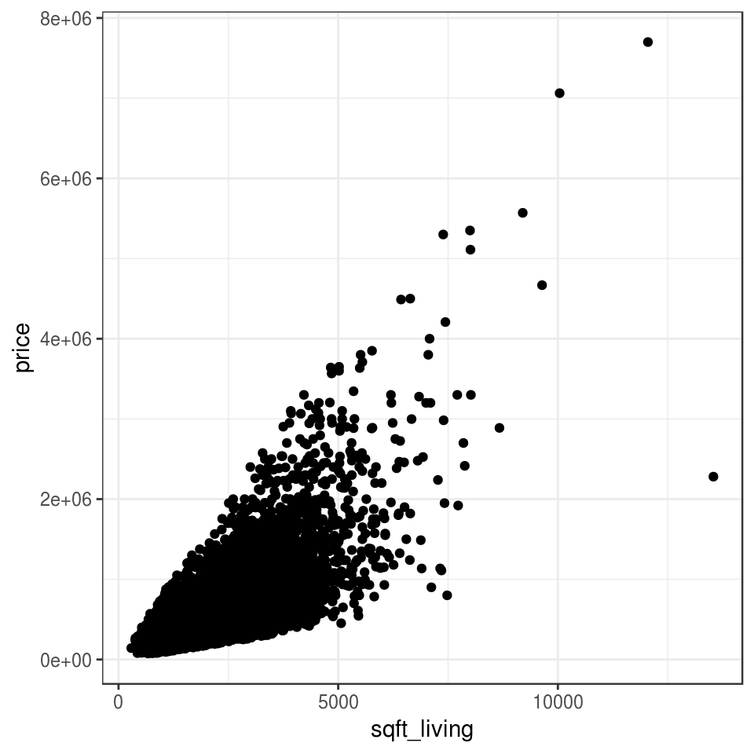

```r
library(ggplot2)
p1 <- ggplot(data = housedata, aes(x = sqft_living, y = price)) +
  geom_point() +
  theme_bw()
p1
```

Overplotting is problematic. What should we do?

- Consider making the plotting shape smaller.
- Make the points semitransparent (`alpha`).
- Bin the data into rectangles.
- Bin the data into hexagons.

### 0.0.1 Using `alpha`

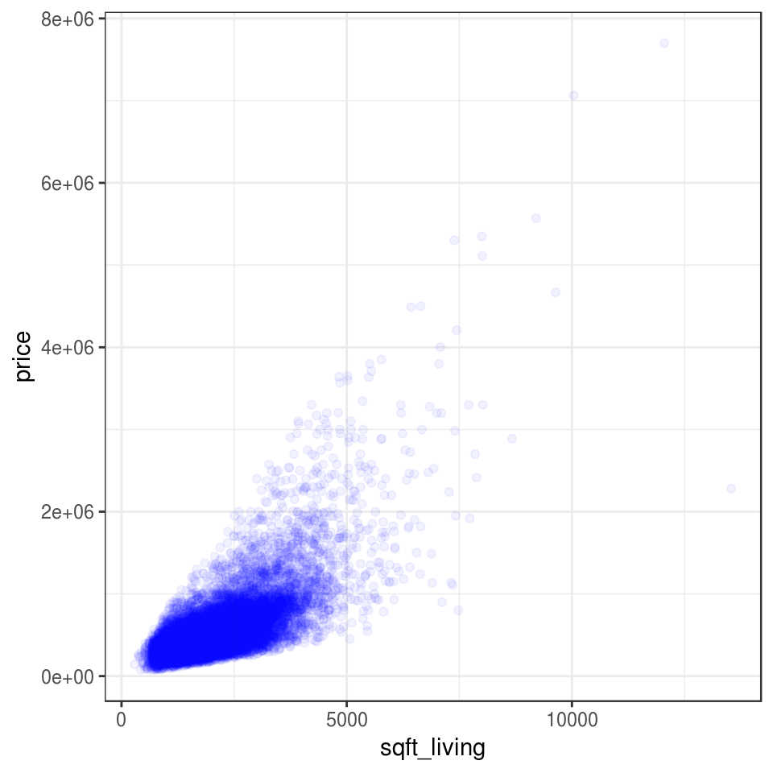

```r
p2 <- ggplot(data = housedata, aes(x = sqft_living, y = price)) +
        geom_point(alpha = 0.05, color = "blue") +
        theme_bw()
p2
```

### 0.0.2 Using rectangles

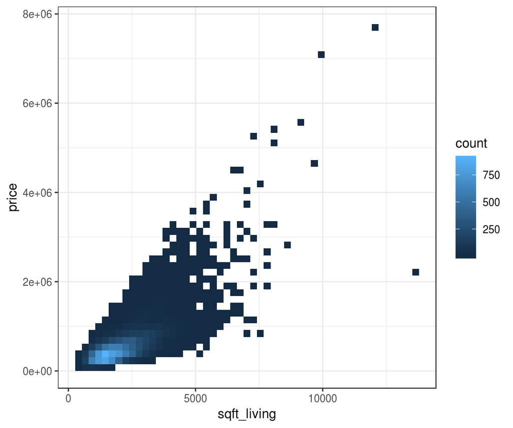

```r
p3 <- ggplot(data = housedata, aes(x = sqft_living, y = price)) +
        stat_bin2d(bins = 50) +
        theme_bw()
p3
```

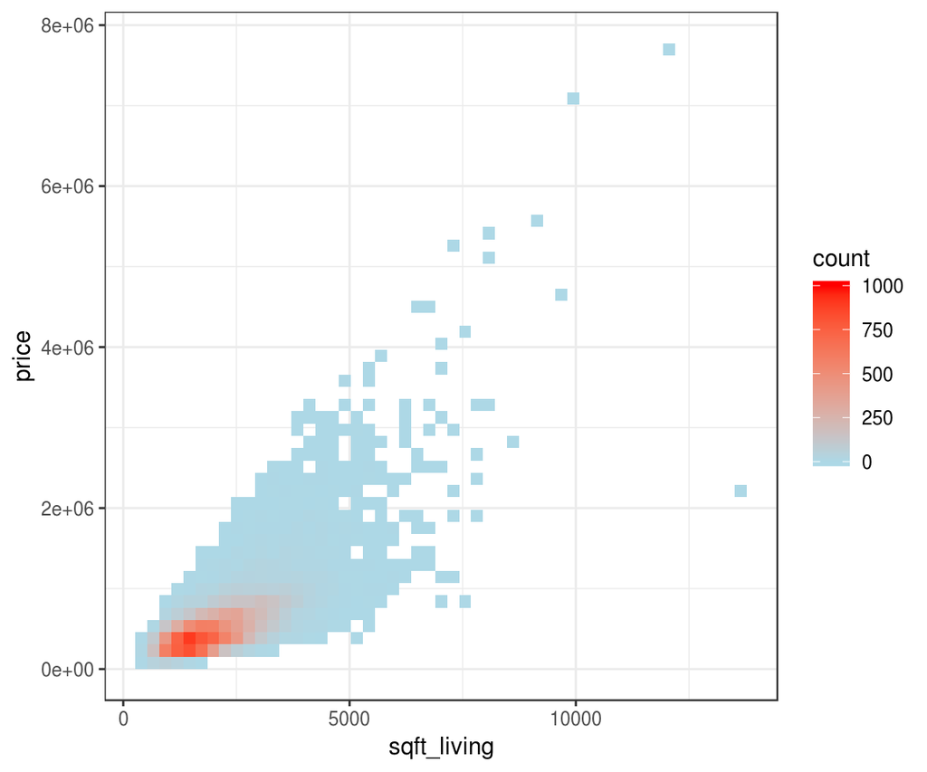

```r
p4 <- ggplot(data = housedata, aes(x = sqft_living, y = price)) +
        stat_bin2d(bins = 50) +
        scale_fill_gradient(low = "lightblue", high = "red",
                            limits = c(0, 1000)) +
        theme_bw()
p4
```

### 0.0.3 Using hexagons

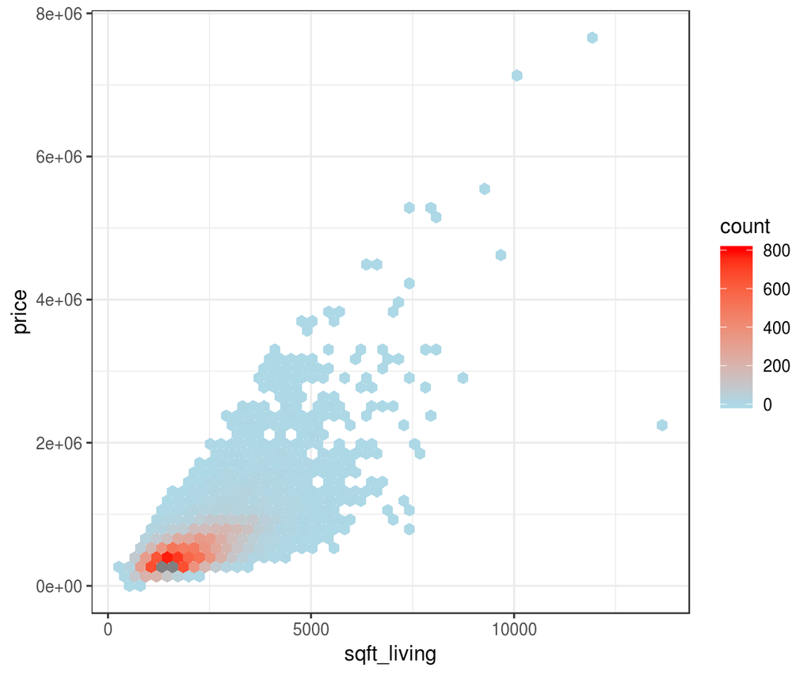

```r
p5 <- ggplot(data = housedata, aes(x = sqft_living, y = price)) +
        stat_binhex(bins = 50) +
        scale_fill_gradient(low = "lightblue", high = "red",
                            limits = c(0, 800), breaks = seq(0, 800, by = 200)) +
        theme_bw()
p5
```

**Note* For both `stat_bin2d` and `stat_binhex`, if you manually specify the range, and there is a bin that falls outside that range because it has too many or too few points, that bin will show up as grey rather than the color at the high or low end of the range. Observe the gray hexagons in the lower left corner of the above graph.

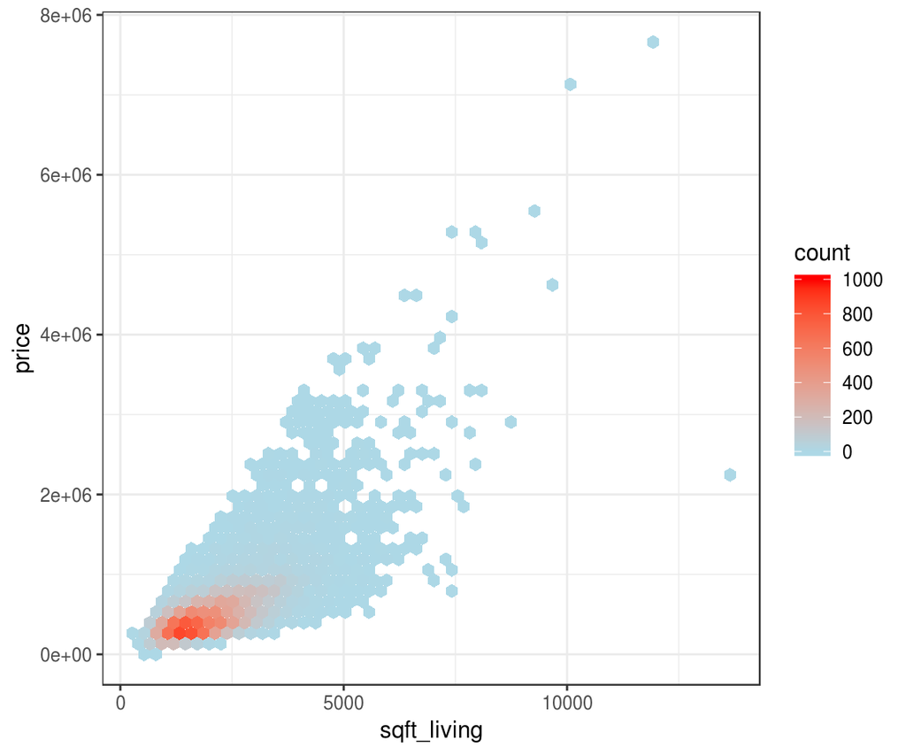

```r
p6 <- ggplot(data = housedata, aes(x = sqft_living, y = price)) +
        stat_binhex(bins = 50) +
        scale_fill_gradient(low = "lightblue", high = "red",
                            limits = c(0, 1000), breaks = seq(0, 1000, by = 200)) +
        theme_bw()
p6
```

```r
# Correlation matric
cor(housedata1)
```

```
                   price    bedrooms  bathrooms sqft_living     sqft_lot
price         1.00000000  0.31284286 0.52334477  0.70291635  0.088238107
bedrooms      0.31284286  1.00000000 0.52923162  0.59105983  0.030179053
bathrooms     0.52334477  0.52923162 1.00000000  0.75455302  0.082139581
sqft_living   0.70291635  0.59105983 0.75455302  1.00000000  0.166967283
sqft_lot      0.08823811  0.03017905 0.08213958  0.16696728  1.000000000
floors        0.25235756  0.18028523 0.50066694  0.35267511 -0.002951851
view          0.39102268  0.07884375 0.18312596  0.27981310  0.069978368
sqft_above    0.60527752  0.49174312 0.68455295  0.87631944  0.176005462
sqft_basement 0.33122956  0.31056084 0.29077234  0.44288611  0.018691884
lat           0.30948443 -0.01002422 0.02676418  0.05693083 -0.085417697
long          0.02131272  0.13604729 0.22151426  0.23737409  0.225347502
sqft_living15 0.58348082  0.40306677 0.56816564  0.75627424  0.147707827
sqft_lot15    0.08080643  0.02784234 0.08467962  0.17830644  0.727774079
                    floors         view   sqft_above sqft_basement
price          0.252357558  0.391022681  0.605277522    0.33122956
bedrooms       0.180285231  0.078843754  0.491743119    0.31056084
bathrooms      0.500666944  0.183125959  0.684552945    0.29077234
sqft_living    0.352675112  0.279813103  0.876319445    0.44288611
sqft_lot      -0.002951851  0.069978368  0.176005462    0.01869188
floors         1.000000000  0.026258735  0.522710921   -0.24145116
view           0.026258735  1.000000000  0.163954243    0.27514730
sqft_above     0.522710921  0.163954243  1.000000000   -0.04379916
sqft_basement -0.241451164  0.275147303 -0.043799158    1.00000000
lat            0.049952734  0.008885553  0.001422037    0.11541978
long           0.125918561 -0.076033506  0.341128260   -0.14261452
sqft_living15  0.280417017  0.279937620  0.732554007    0.20500421
sqft_lot15    -0.007389463  0.068809179  0.188503973    0.01894595
                       lat        long sqft_living15   sqft_lot15
price          0.309484427  0.02131272    0.58348082  0.080806426
bedrooms      -0.010024220  0.13604729    0.40306677  0.027842339
bathrooms      0.026764178  0.22151426    0.56816564  0.084679619
sqft_living    0.056930825  0.23737409    0.75627424  0.178306444
sqft_lot      -0.085417697  0.22534750    0.14770783  0.727774079
floors         0.049952734  0.12591856    0.28041702 -0.007389463
view           0.008885553 -0.07603351    0.27993762  0.068809179
sqft_above     0.001422037  0.34112826    0.73255401  0.188503973
sqft_basement  0.115419784 -0.14261452    0.20500421  0.018945951
lat            1.000000000 -0.13331116    0.04993821 -0.089826111
long          -0.133311159  1.00000000    0.33399885  0.253890095
sqft_living15  0.049938206  0.33399885    1.00000000  0.184561578
sqft_lot15    -0.089826111  0.25389009    0.18456158  1.000000000
```

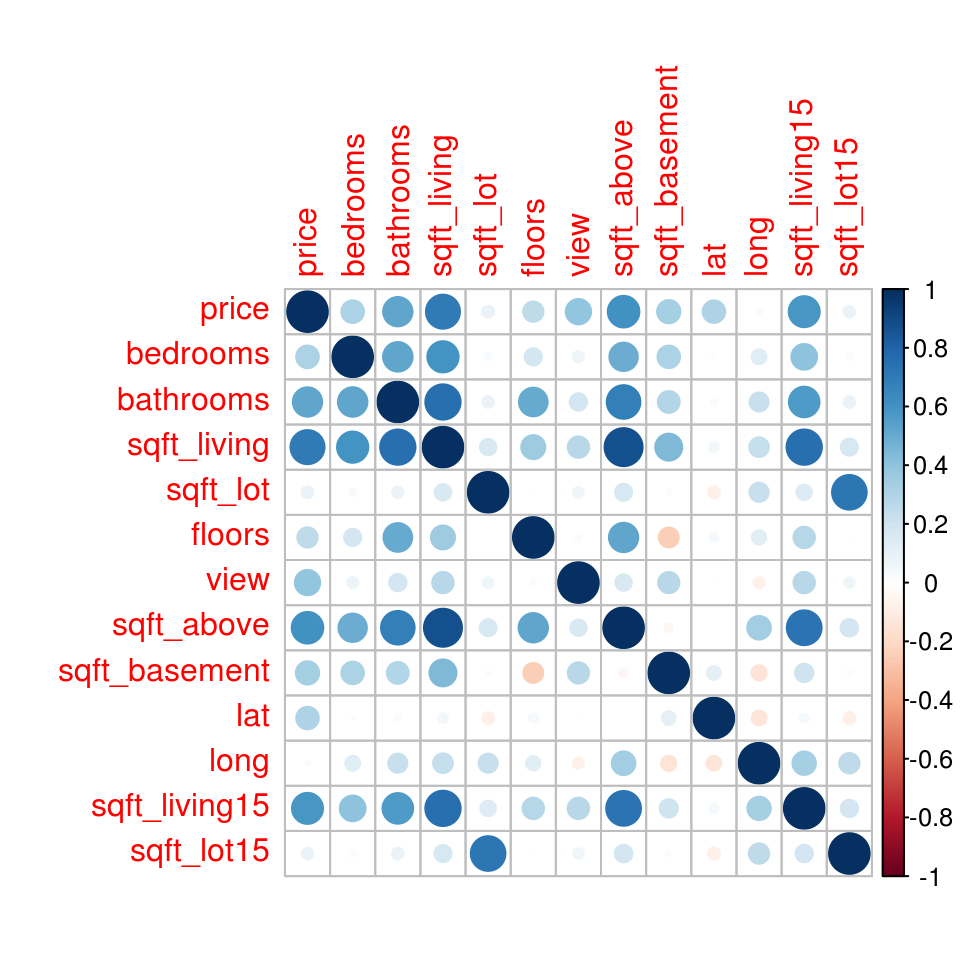

```r
# Corrplot
library(corrplot)
corrplot(cor(housedata1))
```

## 0.1 What features might be visible in a scatterplot?

- Causal relationships (linear and nonlinear) - One variable may have a direct influence on another in some way.
- Associations - Variables may be associated with on another without being directly causally related.
- Outliers of groups of outliers - Cases can be outliers in two dimensions without being outliers in either dimension separately.
- Clusters - Sometimes there are groups of cases which are separate from the rest of the data.
- Gaps - Occasionally, particular combinations of values do not occur.
- Barriers - Some combinations of values may not be possible
- Conditional relationship - Sometimes the relationship between two variables is better summarized by a conditional description that by a function.

Use a simple linear model to predict the price of a house with 2,500 $\text{ft}^2$.

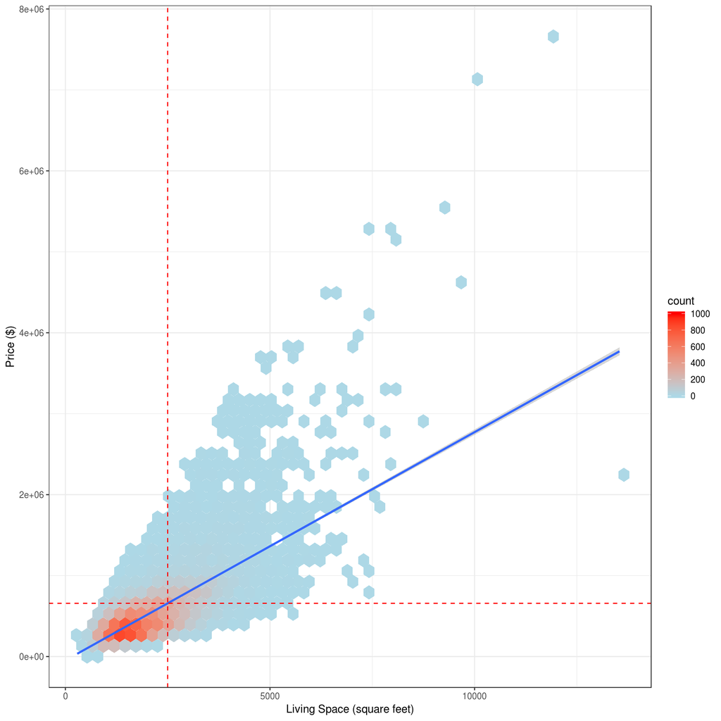

```r
p6 + geom_smooth(method = "lm") +
  geom_vline(xintercept = 2500,linetype = "dashed", color = "red") +
  geom_hline(yintercept = predict(slm, newdata = data.frame(sqft_living = 2500)), linetype = "dashed", color = "red") +
  labs(x = "Living Space (square feet)", y = "Price ($)")
```

`mod.zip` most basic model.

`mod.all` all current features except `sqft_basement`.

Your goal is to create a model with as small a test error as possible. Note that the square root of the training RSS from model `mod.all` is $1.5018076\times 10^{5}$.

```r
library(ggmap)
KingMap <-
  get_map(
    location = c(lon = -122.1, lat = 47.48),
    zoom = 10,
    source = "google",
    maptype = "roadmap"
  )
ggmap(KingMap) +
  geom_point(
    aes(x = housedata$long, y = housedata$lat),
    data = housedata,
    alpha = .2,
    color = "blue",
    size = 0.01
  ) +
  geom_point(
    aes(x = housedataT$long, y = housedataT$lat),
    data = housedataT,
    alpha = .2,
    color = "red",
    size = 0.01
  ) +
  ggtitle("Houses Sold in King County, Wa (2014-2015)") +
  labs(x = "longitute", y = "latitude")
```

[output not shown]